# Project: Investigate a Dataset - [TMDb movie dataset]

- Introduction
- Data Wrangling
- Exploratory Data Analysis
- Conclusions

## Introduction

In this project we explore the the TMDb movie data to identify and investigate patterns and relationships between/among the features in the data that can help draw meaningful conclusions on what influences the popularity and general success of movies.

### Dataset Description

The dataset has 10866 entries and 21 columns. Below are column names and what they represent.

1. id -------------- unique index of each movie
2. imdb_id ----------- ----imdb index
3. popularity ----------- ---measure of how polular a movie is
4. budget ------------- amount of money spent on the movie
5. revenue------------- amount of money made from the movie
6. original_title -------- movie title
7. cast ----------- actors in the movie
8. homepage --------------- webpage of the movie
9. director ---------------movie director
10. tagline ------------- slogan of the movie
11. keywords----------- keywords in the movie
12. overview -------------- blurb of the movie
13. runtime ------------- length of the movie in mimutes
14. genres ------- the style categories that the movie falls into
15. production_companies-------- company that produced the movie
16. release_date --------------- when the movie was released
17. vote_count ----------- number of people who liked the movie
18. vote_average ------------ average of vote count
19. release_year ---------- the year the movie was realeased
20. budget_adj ------ movie budget in terms of 2010 dollars
21. revenue_adj -------- movie revenuw in terms of 2010 dollars

### Question(s) for Analysis

To investigate the dataset, we need to use some python packages which we import:

```python
# importing libraries and packages

import numpy as np
import pandas as pd
import matplotlib.pyplot as plt
import seaborn as sns

import warnings
warnings.filterwarnings('ignore')
```

```python
# Upgrade pandas to use dataframe.explode() function.
#!pip install --upgrade pandas==0.25.0
```

## Data Wrangling

We would assess the data using some numpy and pandas commands.

First we load the data.

```python
# Load your data and print out a few lines. Perform operations to inspect data
#types and look for instances of missing or possibly errant data.
movie_data = pd.read_csv('tmdb-movies.csv')
movie_data.head()
```

|  | id | imdb_id | popularity | budget | revenue | original_title | cast | homepage | director | tagline | ... | overview | runtime | genres | production_companies | release_date | vote_count | vote_average | release_year | budget_adj | revenue_adj |
| --- | --- | --- | --- | --- | --- | --- | --- | --- | --- | --- | --- | --- | --- | --- | --- | --- | --- | --- | --- | --- | --- |
| 0 | 135397 | tt0369610 | 32.985763 | 150000000 | 1513528810 | Jurassic World | Chris Pratt\|Bryce Dallas Howard\|Irrfan Khan\|Vi... | http://www.jurassicworld.com/ | Colin Trevorrow | The park is open. | ... | Twenty-two years after the events of Jurassic ... | 124 | Action\|Adventure\|Science Fiction\|Thriller | Universal Studios\|Amblin Entertainment\|Legenda... | 6/9/15 | 5562 | 6.5 | 2015 | 1.379999e+08 | 1.392446e+09 |
| 1 | 76341 | tt1392190 | 28.419936 | 150000000 | 378436354 | Mad Max: Fury Road | Tom Hardy\|Charlize Theron\|Hugh Keays-Byrne\|Nic... | http://www.madmaxmovie.com/ | George Miller | What a Lovely Day. | ... | An apocalyptic story set in the furthest reach... | 120 | Action\|Adventure\|Science Fiction\|Thriller | Village Roadshow Pictures\|Kennedy Miller Produ... | 5/13/15 | 6185 | 7.1 | 2015 | 1.379999e+08 | 3.481613e+08 |
| 2 | 262500 | tt2908446 | 13.112507 | 110000000 | 295238201 | Insurgent | Shailene Woodley\|Theo James\|Kate Winslet\|Ansel... | http://www.thedivergentseries.movie/#insurgent | Robert Schwentke | One Choice Can Destroy You | ... | Beatrice Prior must confront her inner demons ... | 119 | Adventure\|Science Fiction\|Thriller | Summit Entertainment\|Mandeville Films\|Red Wago... | 3/18/15 | 2480 | 6.3 | 2015 | 1.012000e+08 | 2.716190e+08 |
| 3 | 140607 | tt2488496 | 11.173104 | 200000000 | 2068178225 | Star Wars: The Force Awakens | Harrison Ford\|Mark Hamill\|Carrie Fisher\|Adam D... | http://www.starwars.com/films/star-wars-episod... | J.J. Abrams | Every generation has a story. | ... | Thirty years after defeating the Galactic Empi... | 136 | Action\|Adventure\|Science Fiction\|Fantasy | Lucasfilm\|Truenorth Productions\|Bad Robot | 12/15/15 | 5292 | 7.5 | 2015 | 1.839999e+08 | 1.902723e+09 |
| 4 | 168259 | tt2820852 | 9.335014 | 190000000 | 1506249360 | Furious 7 | Vin Diesel\|Paul Walker\|Jason Statham\|Michelle ... | http://www.furious7.com/ | James Wan | Vengeance Hits Home | ... | Deckard Shaw seeks revenge against Dominic Tor... | 137 | Action\|Crime\|Thriller | Universal Pictures\|Original Film\|Media Rights ... | 4/1/15 | 2947 | 7.3 | 2015 | 1.747999e+08 | 1.385749e+09 |

5 rows × 21 columns

```python
#checking the size
movie_data.shape
```

```
(10866, 21)
```

```python
#checking the nature of values in the columns
movie_data.dtypes
```

```
id                        int64
imdb_id                  object
popularity              float64
budget                    int64
revenue                   int64
original_title           object
cast                     object
homepage                 object
director                 object
tagline                  object
keywords                 object
overview                 object
runtime                   int64
genres                   object
production_companies     object
release_date             object
vote_count                int64
vote_average            float64
release_year              int64
budget_adj              float64
revenue_adj             float64
dtype: object
```

```python
# removing columns that are not needed
nmovie_data=movie_data.drop(['id', 'imdb_id', 'homepage', 'overview', 'tagline', 'keywords', 'director','production_companies','cast'],axis=1)
nmovie_data.head()
```

|  | popularity | budget | revenue | original_title | runtime | genres | release_date | vote_count | vote_average | release_year | budget_adj | revenue_adj |
| --- | --- | --- | --- | --- | --- | --- | --- | --- | --- | --- | --- | --- |
| 0 | 32.985763 | 150000000 | 1513528810 | Jurassic World | 124 | Action\|Adventure\|Science Fiction\|Thriller | 6/9/15 | 5562 | 6.5 | 2015 | 1.379999e+08 | 1.392446e+09 |
| 1 | 28.419936 | 150000000 | 378436354 | Mad Max: Fury Road | 120 | Action\|Adventure\|Science Fiction\|Thriller | 5/13/15 | 6185 | 7.1 | 2015 | 1.379999e+08 | 3.481613e+08 |
| 2 | 13.112507 | 110000000 | 295238201 | Insurgent | 119 | Adventure\|Science Fiction\|Thriller | 3/18/15 | 2480 | 6.3 | 2015 | 1.012000e+08 | 2.716190e+08 |
| 3 | 11.173104 | 200000000 | 2068178225 | Star Wars: The Force Awakens | 136 | Action\|Adventure\|Science Fiction\|Fantasy | 12/15/15 | 5292 | 7.5 | 2015 | 1.839999e+08 | 1.902723e+09 |
| 4 | 9.335014 | 190000000 | 1506249360 | Furious 7 | 137 | Action\|Crime\|Thriller | 4/1/15 | 2947 | 7.3 | 2015 | 1.747999e+08 | 1.385749e+09 |

```python
#uniqe values in each column
nmovie_data.nunique()
```

```
popularity        10814
budget              557
revenue            4702
original_title    10571
runtime             247
genres             2039
release_date       5909
vote_count         1289
vote_average         72
release_year         56
budget_adj         2614
revenue_adj        4840
dtype: int64
```

```python
 nmovie_data.shape
```

```
(10866, 12)
```

```python
#summary statistics of the data
nmovie_data.describe()
```

|  | popularity | budget | revenue | runtime | vote_count | vote_average | release_year | budget_adj | revenue_adj |
| --- | --- | --- | --- | --- | --- | --- | --- | --- | --- |
| count | 10866.000000 | 1.086600e+04 | 1.086600e+04 | 10866.000000 | 10866.000000 | 10866.000000 | 10866.000000 | 1.086600e+04 | 1.086600e+04 |
| mean | 0.646441 | 1.462570e+07 | 3.982332e+07 | 102.070863 | 217.389748 | 5.974922 | 2001.322658 | 1.755104e+07 | 5.136436e+07 |
| std | 1.000185 | 3.091321e+07 | 1.170035e+08 | 31.381405 | 575.619058 | 0.935142 | 12.812941 | 3.430616e+07 | 1.446325e+08 |
| min | 0.000065 | 0.000000e+00 | 0.000000e+00 | 0.000000 | 10.000000 | 1.500000 | 1960.000000 | 0.000000e+00 | 0.000000e+00 |
| 25% | 0.207583 | 0.000000e+00 | 0.000000e+00 | 90.000000 | 17.000000 | 5.400000 | 1995.000000 | 0.000000e+00 | 0.000000e+00 |
| 50% | 0.383856 | 0.000000e+00 | 0.000000e+00 | 99.000000 | 38.000000 | 6.000000 | 2006.000000 | 0.000000e+00 | 0.000000e+00 |
| 75% | 0.713817 | 1.500000e+07 | 2.400000e+07 | 111.000000 | 145.750000 | 6.600000 | 2011.000000 | 2.085325e+07 | 3.369710e+07 |
| max | 32.985763 | 4.250000e+08 | 2.781506e+09 | 900.000000 | 9767.000000 | 9.200000 | 2015.000000 | 4.250000e+08 | 2.827124e+09 |

#### Results from assessing the movie dataset

Now we do not need all the columns for our analysis so drop the columns that we do not need. The columns: **id, imdb_id, homepage, overview, tagline** and **keywords** are dropped.

We also drop the columns **cast, director** and **production_comanies** because we see that they have unique values which are almost have of the dataset. While they could be factors that influence the popularity of movies, it may not be very interesting to investigate. So the number of columns reduce to $12$.

From the summary statistics, we see among other things that the maximum popularity value is $32.985763$.

We proceed to clean the reduced dataset.

### Data Cleaning

The next step is to clean the data. We look out for the following:

> **missing values**

> **incorrect datatypes**

> **duplicates**

```python
# information about the dataset
nmovie_data.info()
```

```
<class 'pandas.core.frame.DataFrame'>
RangeIndex: 10866 entries, 0 to 10865
Data columns (total 12 columns):
 #   Column          Non-Null Count  Dtype
---  ------          --------------  -----
 0   popularity      10866 non-null  float64
 1   budget          10866 non-null  int64
 2   revenue         10866 non-null  int64
 3   original_title  10866 non-null  object
 4   runtime         10866 non-null  int64
 5   genres          10843 non-null  object
 6   release_date    10866 non-null  object
 7   vote_count      10866 non-null  int64
 8   vote_average    10866 non-null  float64
 9   release_year    10866 non-null  int64
 10  budget_adj      10866 non-null  float64
 11  revenue_adj     10866 non-null  float64
dtypes: float64(4), int64(5), object(3)
memory usage: 1018.8+ KB
```

```python
#dropping missing values
nmovie_data = nmovie_data.dropna()
nmovie_data.head()
```

|  | popularity | budget | revenue | original_title | runtime | genres | release_date | vote_count | vote_average | release_year | budget_adj | revenue_adj |
| --- | --- | --- | --- | --- | --- | --- | --- | --- | --- | --- | --- | --- |
| 0 | 32.985763 | 150000000 | 1513528810 | Jurassic World | 124 | Action\|Adventure\|Science Fiction\|Thriller | 6/9/15 | 5562 | 6.5 | 2015 | 1.379999e+08 | 1.392446e+09 |
| 1 | 28.419936 | 150000000 | 378436354 | Mad Max: Fury Road | 120 | Action\|Adventure\|Science Fiction\|Thriller | 5/13/15 | 6185 | 7.1 | 2015 | 1.379999e+08 | 3.481613e+08 |
| 2 | 13.112507 | 110000000 | 295238201 | Insurgent | 119 | Adventure\|Science Fiction\|Thriller | 3/18/15 | 2480 | 6.3 | 2015 | 1.012000e+08 | 2.716190e+08 |
| 3 | 11.173104 | 200000000 | 2068178225 | Star Wars: The Force Awakens | 136 | Action\|Adventure\|Science Fiction\|Fantasy | 12/15/15 | 5292 | 7.5 | 2015 | 1.839999e+08 | 1.902723e+09 |
| 4 | 9.335014 | 190000000 | 1506249360 | Furious 7 | 137 | Action\|Crime\|Thriller | 4/1/15 | 2947 | 7.3 | 2015 | 1.747999e+08 | 1.385749e+09 |

```python
#duplicates
sum(nmovie_data.duplicated())
```

```
1
```

```python
#drop duplicates
nmovie_data.drop_duplicates(inplace=True)
```

```python
nmovie_data.shape
```

```
(10842, 12)
```

#### Results from cleaning the dataset

> **missing values:** from assessment, the column **genres** has $23$ missing values. Given that the data type is string and the missing values are not too many, we drop these missing values.

> **incorrect datatypes:** all the columns of the dataset are in have the appropriate data type format so there is no need to make changes.

> **duplicates:** there is one duplicate in the dataset and we remove it.

Now that we have a clean dataset we proceed to explore the relationships between the columns using visuals.

## Exploratory Data Analysis

In this section we explore the patterns of individual varables and the relationships between variables. We do this by posing questions and finding answeres from visualizations.

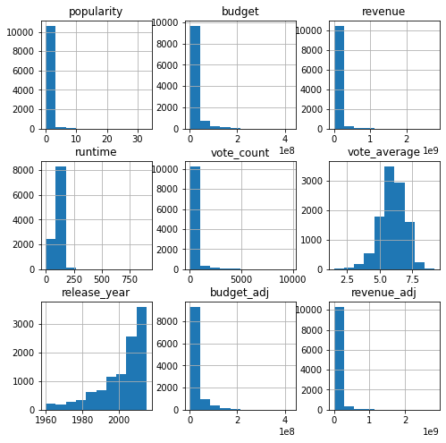

```python
nmovie_data.hist(figsize= (8,8));
```

```python
#function for plotting

def plotting(y,x):
    plt.figure(figsize=(10,8))
    plot = plt.scatter(x= x, y= y, data= nmovies, color = 'r')
    plt.xlabel(x)
    plt.ylabel(y)
    plt.title(x + ' and ' + y)
    plt.show()
    return plot
    plt.show()
```

### Research Question 1 ( what is the relationship between popularity and budget ?)

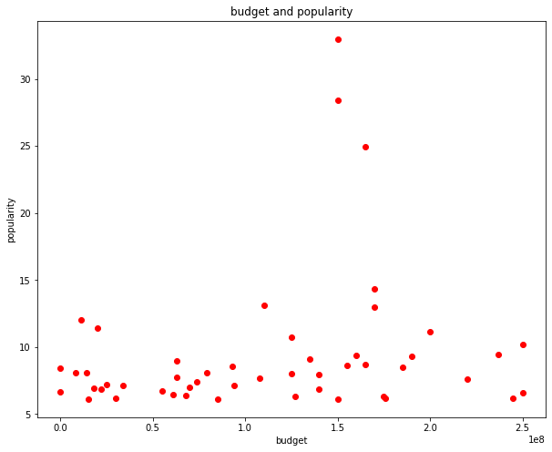

```python
nmovies=nmovie_data.sort_values(by=['popularity'], ascending =False).head(50)
plotting('popularity', 'budget')
plt.show()
```

**Given the number of entries in the dataset we sort the data by the column popularity and plot the first $50$ most popular entries against their budgets.**

**It is observed from the scatterplot that there is little to no association with the popularity and budget. Except for $3$ outliers that have popularity above $20$ and a budget below $200$ million, all top $50$ popular movies in the dataset, have popularity less than or equal to $15$.**

### Research Question 2 ( what is the relationship between popularity and runtime?)

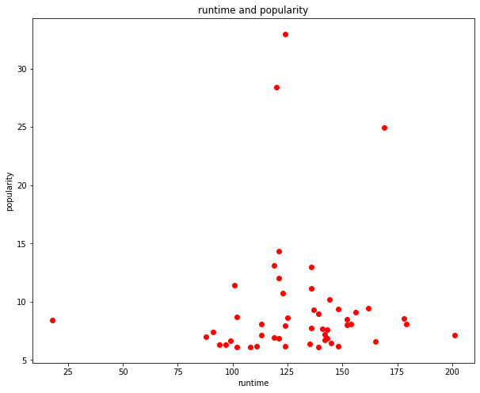

```python
plotting( 'popularity', 'runtime')
plt.show()
```

**Plotting the top $50$ popular movies against their runtime, reveals that ,ost movies have runtime between $75$ minutes and $175$ minutes. Similar to the budget, it can be observed that there is very little association between popularity and the runtime of a movie.**

### Research Question 3 (What has been the general popularity of movies from year to year?)

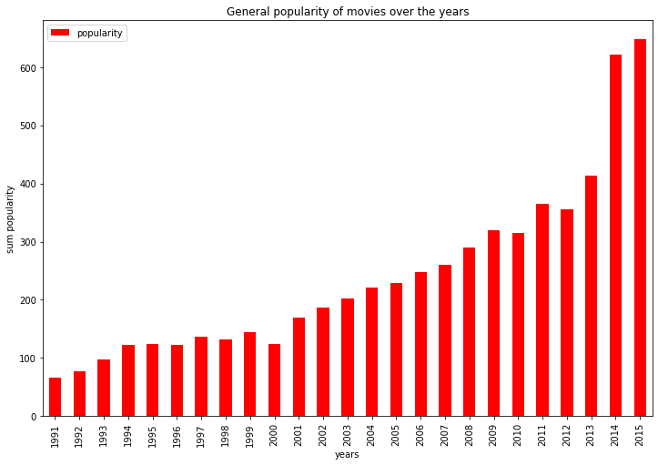

```python
poplarity_pattern = nmovie_data.groupby('release_year').sum().reset_index().tail(25)
poplarity_pattern.plot.bar(x='release_year',y='popularity', figsize = (12,8), color='r', xlabel= 'years', ylabel = 'sum popularity',
                           title ="General popularity of movies over the years")
plt.show()
```

**We would also like to investigate the general popularity of movies over the years, irrespective of genres. We sum the popularity of movies by release year. For visibility, the plot starts from the year $1991$ and we see that the general trend in the popularity of movies is an upward trend. We however see that in some years such as, $2000$, $2010$ and $2012$ there is a dip in the popularity of movies which could be caused by external factors outside the movie industry or space.**

### Research Question 3 (Which genre has the highest popularity?)

```python
temp2 = nmovie_data.groupby('genres').sum().reset_index()
category = {}
for (elm1,elm2) in temp2[['genres','popularity']].values:
    splt = elm1.split('|')
    for elm3 in splt:
        if (elm3 not in category ):
            category[elm3] = elm2
        else:
            category[elm3] += elm2
```

```python
temp3 = nmovie_data.groupby(['genres','release_year']).sum().reset_index()
category= {}
for (elm1,elm2) in temp3[['genres','popularity']].values:
    splt = elm1.split('|')
    for elm3 in splt:
        if (elm3 not in category):
            category[elm3] = elm2
        else:
            category[elm3] += elm2
genpop =pd.DataFrame.from_dict(category, orient='index').reset_index()
genpop.columns=['genres', 'sum_popularity']
genpop
```

|  | genres | sum_popularity |
| --- | --- | --- |
| 0 | Action | 2208.238255 |
| 1 | Adventure | 1697.915054 |
| 2 | Animation | 595.674975 |
| 3 | Comedy | 2247.759649 |
| 4 | Drama | 2815.517715 |
| 5 | Family | 968.388793 |
| 6 | Fantasy | 909.441171 |
| 7 | Mystery | 558.909827 |
| 8 | Science Fiction | 1230.902062 |
| 9 | Horror | 761.788804 |
| 10 | Crime | 1008.635823 |
| 11 | Thriller | 2155.723620 |
| 12 | Foreign | 36.001309 |
| 13 | Romance | 1013.644468 |
| 14 | War | 196.474450 |
| 15 | Western | 97.451554 |
| 16 | Music | 198.827043 |
| 17 | History | 192.362605 |
| 18 | TV Movie | 45.239592 |
| 19 | Documentary | 94.344445 |

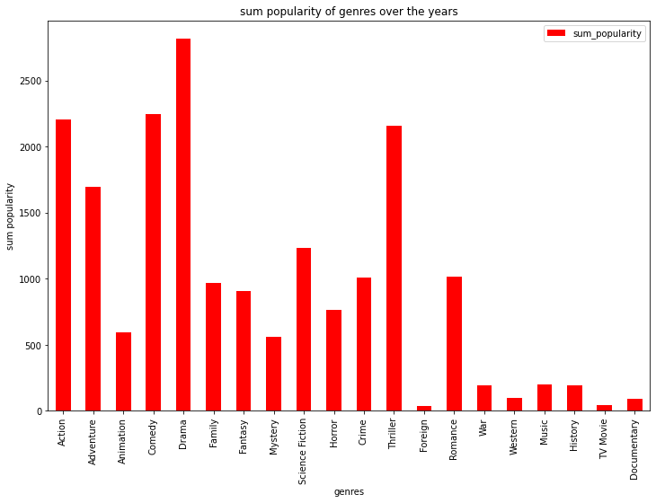

```python
genpop.plot.bar(x='genres',y='sum_popularity', color = 'r', ylabel='sum popularity',figsize=(12,8))
plt.title("sum popularity of genres over the years")
plt.show()
```

### Research Question 4 (Which genres are most popular from year to year?)

```python
temp3 = nmovie_data.groupby(['genres','release_year']).sum().reset_index()

category2 = {}
l = {}
for (elm1,elm2,year) in temp3[['genres','popularity','release_year']].values:
    splt = elm1.split('|')
    if year in category2:
        l = category2[year]
    else:
        l={}
    for elm3 in splt:
        if (elm3 not in l):
            l[elm3] = elm2
        else:
            l[elm3] += elm2
    category2[year] = l
```

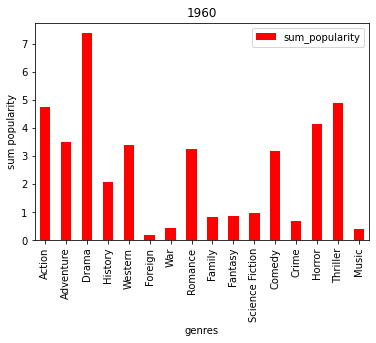

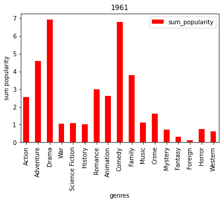

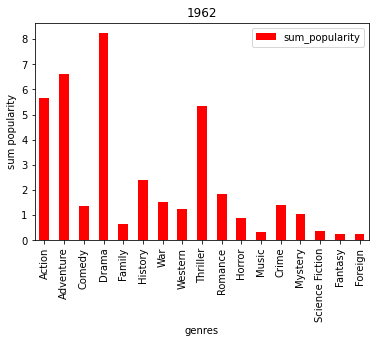

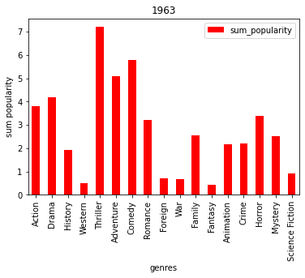

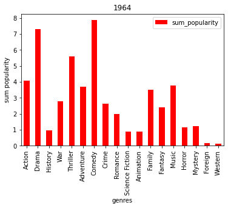

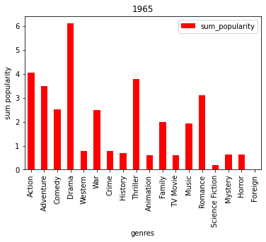

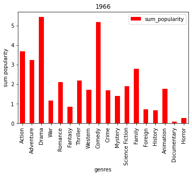

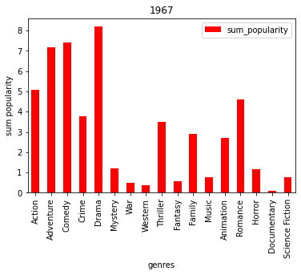

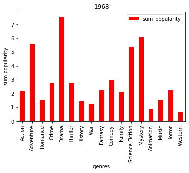

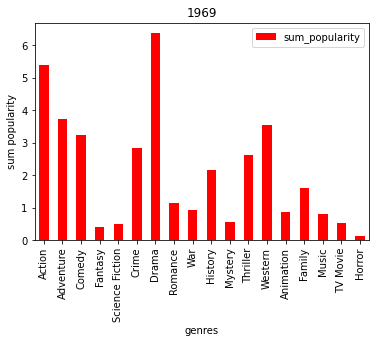

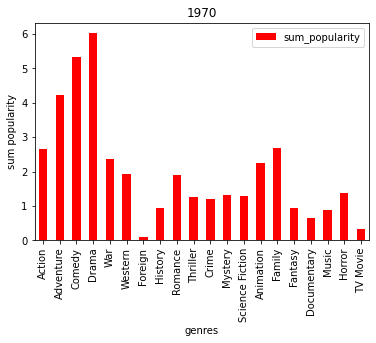

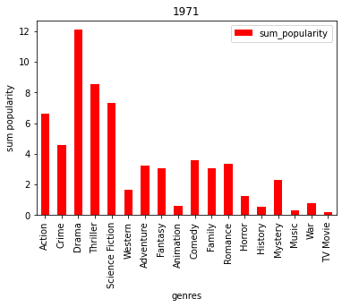

[44 more figures not shown]

```python
category2 = dict(sorted(category2.items()))
for year in category2:
    dat = category2[year]
    dat =pd.DataFrame.from_dict(dat, orient='index').reset_index()
    dat.columns=['genres', 'sum_popularity']
    dat.plot.bar(x='genres',y='sum_popularity', color = 'r', ylabel='sum popularity',title=str(year))
```

## Conclusions

**The investigations carried out on the movie dataset show that there are several factors that could influence the popularity and hence success of a movie, none the less we may not be able to easily generalise these factors to determine the success or popularity of all movies. Additionally, this investigation only scratch the surface of the possible research questions that could be posed on this dataset and is by no means a conclusive study.**

References:

1. geeksforgeeks
2. stack overflow